# Lab 5 - BINF 6310

Erin Tsai

### Problem 1:

##### We will utilize our RNA seq dataset of E. Coli genes from mice. The URL is here: http://afodor.github.io/classes/stats2015/longitdunalRNASeqData.zip

##### Read and Normalize the counts table(“nc101_scaff_dataCounts.txt “ into R).

###### (The first 3 columns are “day 2”, the next 3 columns are “week 12” and the last 5 are “week 18”). Remember, that day 2 is before the mice have inflammation symptoms, week 12 is associated with inflammation and week 18 is associated with cancer.

```r
myT = read.table(file = "longitdunalRNASeqData/nc101_scaff_dataCounts.txt", sep = "\t", header = TRUE, row.names = 1)

#remove rare genes
myT = myT[apply(myT, 1, median) > 5,]

myTNorm = myT
for(i in 1:ncol(myT)){
  colSum = sum(myT[,i])
  myTNorm[,i] = myTNorm[,i]/colSum
}
```

### Problem 2:

##### For every row in the normalized spreadsheet, run three t-tests (“day 2” vs. “week 12”, “day 2” vs. “week 18” and “week 12” vs. “week 18”). At a p < .05 threshold fill in the following table:

```r
#genes significant at p < 0.05 uncorrected
day2week12_pvals = vector()
day2week12_unc = 0
day2week18_pvals = vector()
day2week18_unc = 0
week12week18_pvals = vector()
week12week18_unc = 0

for (i in 1:nrow(myTNorm)){
  day2 = myTNorm[i,1:3]
  week12 = myTNorm[i,4:6]
  week18 = myTNorm[i,7:11]
  day2week12_pvals[i] = t.test(day2,week12,var.equal = FALSE)$p.value
  if(day2week12_pvals[i] <= 0.05){
    day2week12_unc = day2week12_unc + 1
  }

  day2week18_pvals[i] = t.test(day2,week18,var.equal = FALSE)$p.value
  if(day2week18_pvals[i] <= 0.05){
    day2week18_unc = day2week18_unc + 1
  }

  week12week18_pvals[i] = t.test(week12,week18,var.equal = FALSE)$p.value
  if(week12week18_pvals[i] <= 0.05){
    week12week18_unc = week12week18_unc + 1
  }
}
unc_pval_counts = c(day2week12_unc, day2week18_unc, week12week18_unc)

#genes significant at p < 0.05 FDR corrected pvals
d2w12_fdr_cor = sum(p.adjust(day2week12_pvals, 'BH') < 0.05)
d2w18_fdr_cor = sum(p.adjust(day2week18_pvals, 'BH') < 0.05)
w12w18_fdr_cor = sum(p.adjust(week12week18_pvals, 'BH') < 0.05)
cor_fdr_counts = c(d2w12_fdr_cor, d2w18_fdr_cor, w12w18_fdr_cor)

#Bonferroni corrected
d2w12_bon_correct = sum(p.adjust(day2week12_pvals, "bonferroni") <= 0.05)
d2w18_bon_correct = sum(p.adjust(day2week18_pvals, "bonferroni") <= 0.05)
w12w18_bon_correct = sum(p.adjust(week12week18_pvals, "bonferroni") <= 0.05)
cor_bon_counts = c(d2w12_bon_correct, d2w18_bon_correct, w12w18_bon_correct)

#Full table results
full_table_counts = data.frame(unc_pval_counts, cor_fdr_counts, cor_bon_counts)
rownames(full_table_counts) = c("Day2 v. Week12", "Day2 v. Week18", "Week12 v. Week18")
colnames(full_table_counts) = c("Genes with p < 0.05 uncorrected", "Genes with p <0.05 BH FDR corrected", "Genes with p <0.05 Bonferroni corrected")

full_table_counts
```

```
##                  Genes with p < 0.05 uncorrected
## Day2 v. Week12                               398
## Day2 v. Week18                              1243
## Week12 v. Week18                             810
##                  Genes with p <0.05 BH FDR corrected
## Day2 v. Week12                                     0
## Day2 v. Week18                                   279
## Week12 v. Week18                                  15
##                  Genes with p <0.05 Bonferroni corrected
## Day2 v. Week12                                         0
## Day2 v. Week18                                         3
## Week12 v. Week18                                       1
```

### Problem 3:

##### Make histograms of all the uncorrected p-values for each of the three campanions. Are any of the distributions uniform?

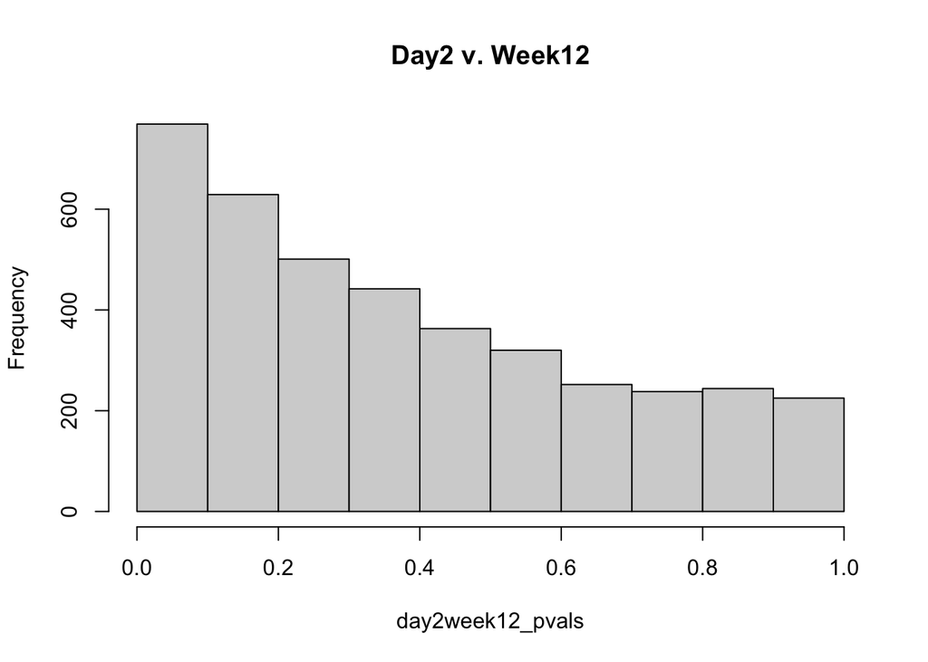

```r
hist_d2w12 = hist(day2week12_pvals, main = "Day2 v. Week12")
```

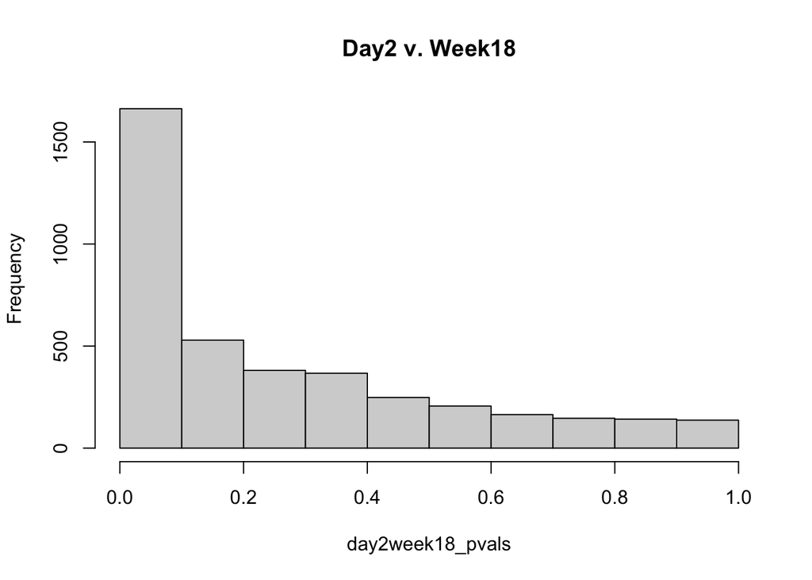

```r
hist_d2w18 = hist(day2week18_pvals, main = "Day2 v. Week18")
```

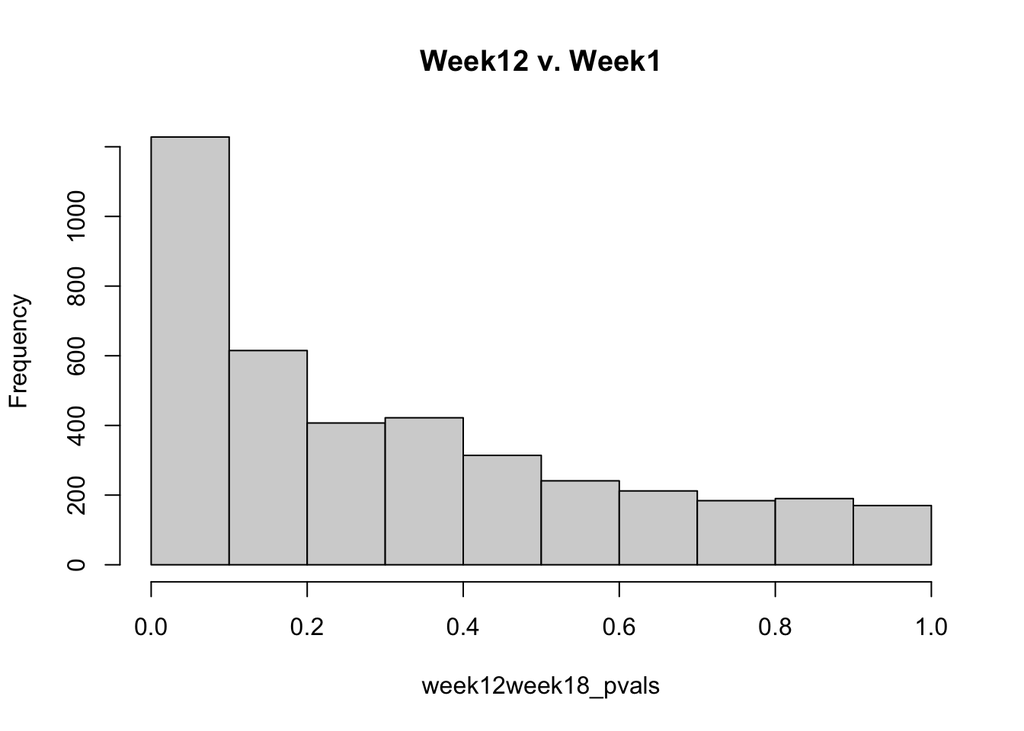

```r
hist_w12w18 = hist(week12week18_pvals, main = "Week12 v. Week1")
```

- None of the histograms have a uniform distribution.

### Problem 4:

##### Based on these data, when is the biggest shift in the transcriptome? Which samples are most different from one another?

```r
sum(hist_d2w12$counts[1:2])
```

```
## [1] 1398
```

```r
sum(hist_d2w18$counts[1:2])
```

```
## [1] 2192
```

```r
sum(hist_w12w18$counts[1:2])
```

```
## [1] 1843
```

- It seems that the biggest shift in transcriptome is from day 2 vs. week 18.
- The sample that seems to be the most different from one another is the day 2 vs. week 18 sample.